# Lab 01 part 2 - Alternative OTU Clustering

## Outline of lab

This is a short (~15 minute) lab demonstrating how you can run an alternative OTU clustering method, that is completely separate from QIIME. Consider it a "fork" in the workflow, at one of the final steps in the process of counting the number of DNA sequence fragments (reads) that came from each bacterial species.

1. UPARSE - Why we might want to use it
2. Sequence data - Inputs for UPARSE
3. `check-trim-sequences.Rmd` - some simple sequence processing using R
4. `run-uparse.sh` - Open, Closed, De Novo OTU clustering
5. Your Turn: Try on example dataset (provided).

## OTU Clustering (background)

In SSU metagenomics, next-generation reads are clustered into Operational Taxonomic Units (OTUs). This requires:

- quality filtering
- dereplication
- discarding singletons (optional)
- clustering into OTUs (typically at a 97% identity threshold)

http://drive5.com/usearch/manual/otu_clustering.html

## UPARSE Reference

- Edgar, R. C. (2013). UPARSE: highly accurate OTU sequences from microbial amplicon reads. Nature Methods, 10(10), 996–998.
- http://www.drive5.com/usearch/manual/
- UPARSE - Part of `usearch` software, low-level C
- QIIME uses by default old version of `usearch` (licensing/distribution issues)

## UPARSE method (very brief)

Identify a set of OTU representative sequences that satisfy

- All pairs of OTU sequences should have < 97% pair-wise sequence identity.
- Chimeric sequences should be discarded.
- All non-chimeric input sequences should match at least one OTU with ≥ 97% identity.

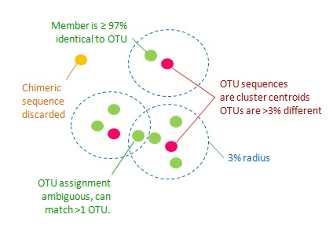

http://www.drive5.com/usearch/manual/uparseotu_algo.html

## UPARSE results/comparison

- Simulated microbiome DNA mixture from 21 bacterial species
- Assess OTU-clustering accuracy of various workflows
- QIIME produced thousands of OTUs, far more than the number of species

## UPARSE results/comparison

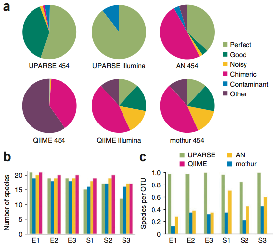

## UPARSE Requires Global-Trimmed Reads

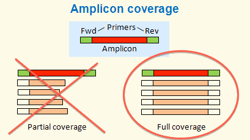

http://www.drive5.com/usearch/manual/global_trimming.html

## Run Trimming `check-trim-sequences.Rmd`

- Execute `check-trim-sequences.Rmd` in its C.D.
- Inspect the code (R), file paths, and threshold values.
- Where does the sequence-trimming happen?
- Why was that threshold chosen?
- Would you have chosen the same threshold?

## Run `run-uparse.sh`

Use the provided bash script to execute UPARSE OTU clustering multiple times

- Open
- Closed
- De Novo

Can you tell which is which? What is the code doing differently?